# Categorical Analysis-Logistic Regression Alternatives

# Problem 2

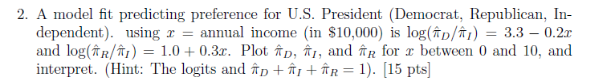

A multinomial logistic regression model predicts preference for U.S. President (Democrat, Republican, Independent) using annual income $x$ = $10,000). The model equations are:

$$\log\left(\frac{\hat{\pi}_D}{\hat{\pi}_I}\right) = 3.3 - 0.2x$$
and
$$\log\left(\frac{\hat{\pi}_R}{\hat{\pi}_I}\right) = 1.0 + 0.3x$$
Plot $\hat{\pi}_D$, $\hat{\pi}_R$ and $\hat\pi_I$

Let $\hat{\pi}_I = \frac{1}{1 + e^{3.3 - 0.2x} + e^{1.0 + 0.3x}}$, then:

$$\hat{\pi}_D = \frac{e^{3.3 - 0.2x}}{1 + e^{3.3 - 0.2x} + e^{1.0 +
0.3x}}, \quad \hat{\pi}_R = \frac{e^{1.0 + 0.3x}}{1 + e^{3.3 - 0.2x} +
e^{1.0 + 0.3x}}$$

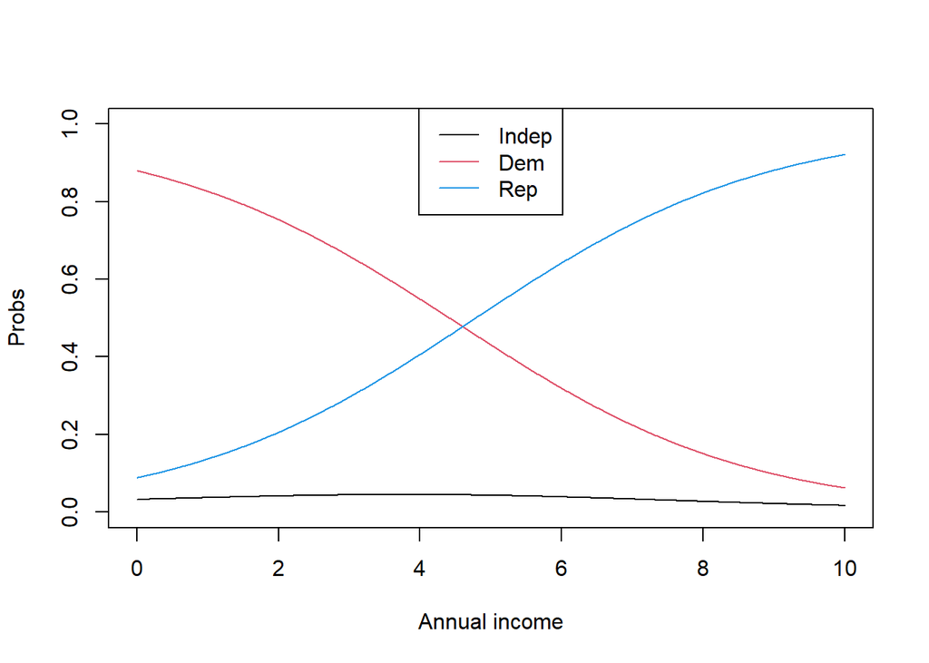

```r
x <- seq(0,10, by=0.01)
pi_I <-1/(exp(3.3-0.2*x) + exp(1.0+0.3*x) + 1)
pi_D <-exp(3.3-0.2*x)/(exp(3.3-0.2*x) + exp(1.0+0.3*x) + 1)
pi_R <-exp(1.0+0.3*x)/(exp(3.3-0.2*x) + exp(1.0+0.3*x) + 1)
plot(x, pi_I, ylim=c(0,1), ylab="Probs", xlab="Annual income", type="l")
lines(x,pi_D, col=2)
lines(x,pi_R, col=4)
legend("top", c("Indep","Dem", "Rep"), lty=c(1,1,1), col=c(1,2,4))
```

# Problem 3

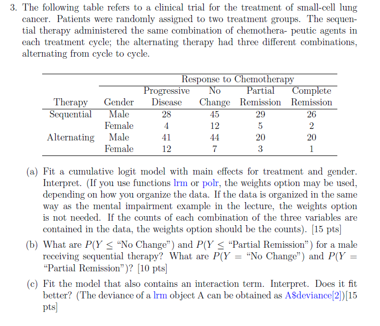

The following table refers to a clinical trial for the treatment of small-cell lung cancer. Patients were randomly assigned to two treatment groups. The sequential therapy administered the same combination of chemotherapeutic agents in each treatment cycle; the alternating therapy had three different combinations, alternating from cycle to cycle.

1. Fit a cumulative logit model with main effects for treatment and gender. Interpret. (If you use functions lrm or polr, the weights option may be used, depending on how you organize the data. If the data is organized in the same way as the mental impairment example in the lecture, the weights option is not needed. If the counts of each combination of the three variables are contained in the data, the weights option should be the counts). [15 pts]

```r
library(rms)
Therapy <- c("S", "A") # Therapy
Gender <- c("M", "F") # Gender
ResChem <- c(1:4) # response scores integers
Count <- c(28,45,29,26,4,12,5,2,41,44,20,20,12,7,3,1)
Data2=cbind(expand.grid( ResChem=ResChem ,Gender=Gender, Therapy=Therapy),
Count)
Data2
```

```
##    ResChem Gender Therapy Count
## 1        1      M       S    28
## 2        2      M       S    45
## 3        3      M       S    29
## 4        4      M       S    26
## 5        1      F       S     4
## 6        2      F       S    12
## 7        3      F       S     5
## 8        4      F       S     2
## 9        1      M       A    41
## 10       2      M       A    44
## 11       3      M       A    20
## 12       4      M       A    20
## 13       1      F       A    12
## 14       2      F       A     7
## 15       3      F       A     3
## 16       4      F       A     1
```

```r
Data2$ResChem.original <- factor(Data2$ResChem)
levels(Data2$ResChem.original) <-c("1:PD","2:NC","3:PR","4:CR")
Data2$ResChem.original
```

```
##  [1] 1:PD 2:NC 3:PR 4:CR 1:PD 2:NC 3:PR 4:CR 1:PD 2:NC 3:PR 4:CR 1:PD 2:NC 3:PR
## [16] 4:CR
## Levels: 1:PD 2:NC 3:PR 4:CR
```

```r
Data2$ResChem.rev <- factor(5-Data2$ResChem)
levels(Data2$ResChem.rev) <- c("CR:1","PR:2","NC:3","PD:4")
Data2$ResChem.rev
```

```
##  [1] PD:4 NC:3 PR:2 CR:1 PD:4 NC:3 PR:2 CR:1 PD:4 NC:3 PR:2 CR:1 PD:4 NC:3 PR:2
## [16] CR:1
## Levels: CR:1 PR:2 NC:3 PD:4
```

```r
mod.lrm <- lrm(ResChem.rev ~ Gender + Therapy, weights=Count, data = Data2)
mod.lrm
```

```
## Logistic Regression Model
##
## lrm(formula = ResChem.rev ~ Gender + Therapy, data = Data2, weights = Count)
##
##
## Frequencies of Responses
##
## CR:1 PR:2 NC:3 PD:4
##    4    4    4    4
##
##
## Sum of Weights by Response Category
##
##   0   1   2   3
##  49  57 108  85
##
##                       Model Likelihood      Discrimination    Rank Discrim.
##                             Ratio Test             Indexes          Indexes
## Obs            16    LR chi2     10.91      R2       0.038    C       0.575
## Sum of weights299    d.f.            2      R2(2,299)0.029    Dxy     0.149
## max |deriv| 9e-07    Pr(> chi2) 0.0043    R2(2,274.7)0.032    gamma   0.236
##                                             Brier    0.135    tau-a   0.121
##
##           Coef    S.E.   Wald Z Pr(>|Z|)
## y>=PR:2    1.3001 0.1850  7.03  <0.0001
## y>=NC:3    0.2492 0.1614  1.54  0.1225
## y>=PD:4   -1.3180 0.1798 -7.33  <0.0001
## Gender=F   0.5414 0.2872  1.89  0.0594
## Therapy=A  0.5807 0.2121  2.74  0.0062
```

2. What are P(Y $\le$ “No Change”) and P(Y $\le$ “Partial Remission”) for a male receiving sequential therapy? What are P(Y = “No Change”) and P(Y =“Partial Remission”)? [10 pts]

Given that:

$P(Y \le NC) = exp(0.2492)/(1+exp(0.2492)) = 0.5619$

$P(Y \le PD) = exp(-1.3180)/(1+exp(-1.3180)) = 0.2111$

$$P(Y = NC) = P(Y \le NC) - P(Y \le PD)
=0.562 -0.211 =0.351$$

$$P(Y = PR) = P(Y \le PR) - P(Y \le No
Change) = 0.786 - 0.562 = 0.224$$

```r
newdata <- data.frame(expand.grid(Therapy = c("S", "A"),
Gender = c("M", "F")))
newdata <- cbind(newdata,predict(mod.lrm,newdata,type="fitted"))
newdata
```

```
##   Therapy Gender   y>=PR:2   y>=NC:3   y>=PD:4
## 1       S      M 0.7858444 0.5619878 0.2111441
## 2       A      M 0.8676962 0.6963377 0.3235821
## 3       S      F 0.8631201 0.6879660 0.3150425
## 4       A      F 0.9184997 0.7975921 0.4511651
```

3. Fit the model that also contains an interaction term. Interpret. Does it fit better? (The deviance of a lrm object A can be obtained as A$deviance[2])[15 pts]

We will use a likelihood ratio test to compare the model fits, we get a p-value of 0.31 which means we do not haave sufficient evidence to reject the null hypothesis and we may conclude that there is no statistical difference between the two models.

```r
fit.lrm.int <- lrm(ResChem.rev ~ Gender*Therapy, weights=Count, data = Data2)
fit.lrm.int
```

```
## Logistic Regression Model
##
## lrm(formula = ResChem.rev ~ Gender * Therapy, data = Data2, weights = Count)
##
##
## Frequencies of Responses
##
## CR:1 PR:2 NC:3 PD:4
##    4    4    4    4
##
##
## Sum of Weights by Response Category
##
##   0   1   2   3
##  49  57 108  85
##
##                       Model Likelihood      Discrimination    Rank Discrim.
##                             Ratio Test             Indexes          Indexes
## Obs            16    LR chi2     11.96      R2       0.042    C       0.575
## Sum of weights299    d.f.            3      R2(3,299)0.030    Dxy     0.149
## max |deriv| 1e-06    Pr(> chi2) 0.0075    R2(3,274.7)0.032    gamma   0.236
##                                             Brier    0.135    tau-a   0.121
##
##                      Coef    S.E.   Wald Z Pr(>|Z|)
## y>=PR:2               1.3452 0.1906  7.06  <0.0001
## y>=NC:3               0.2957 0.1678  1.76  0.0781
## y>=PD:4              -1.2757 0.1844 -6.92  <0.0001
## Gender=F              0.2742 0.3873  0.71  0.4790
## Therapy=A             0.4881 0.2305  2.12  0.0342
## Gender=F * Therapy=A  0.5904 0.5792  1.02  0.3080
```

```r
G2 <- mod.lrm$deviance[2]-fit.lrm.int$deviance[2]
df <- length(coef(fit.lrm.int))-length(coef(mod.lrm))
pchisq(G2,df, lower=F)
```

```
## [1] 0.3062483
```